```r
PV1<-PVdata[1:1440,1] #24*60=1440
for (i in 1:30) {
  PV1<-cbind(PV1,PVdata[((i*1440)+1):((i+1)*1440),1])
}
for(j in 2:12){
  for(i in 1:31){
    PV1<-cbind(PV1,PVdata[(((i-1)*1440)+1):(i*1440),j])
  }
}
PV1<-t(PV1)
```

#Normal distribution

##Parameter estimation

###Parameter estimation - multivariate (dependent) for 1h intervals\

We estimate the values of expectation and the covariance matrix under the assumption of a **multivariate** normal distribution for intervals of 1h:

```r
PV1h<-matrix(rep(0,8928),nrow=372) #hourly values -> take means, 24*372=8928
for(i in 1:372){
  for (j in 1:24){
    PV1h[i,j]<-mean(PV1[i,((j-1)*60+1):(j*60)])
  }
}

estimates_n_dep<-mlest(PV1h) #under assumption of no independence: hourly means and covariance matrix
estimates_n_dep$muhat #estimate of mean (mu)
```

```
##  [1] -3.911e-10 -3.911e-10 -3.911e-10 -3.911e-10 -3.911e-10  4.570e-01
##  [7]  1.288e+02  6.744e+02  1.279e+03  1.791e+03  2.132e+03  2.261e+03
## [13]  2.285e+03  2.118e+03  1.832e+03  1.383e+03  8.038e+02  2.254e+02
## [19]  4.466e+00 -3.911e-10 -3.911e-10 -3.911e-10 -3.911e-10 -3.911e-10
```

```r
estimates_n_dep$sigmahat #estimate of covariance matrix (sigma)
```

```
##            [,1]      [,2]      [,3]      [,4]      [,5]      [,6]
##  [1,] 0.0009987 0.0000000 0.0000000 0.0000000 0.0000000 0.000e+00
##  [2,] 0.0000000 0.0009987 0.0000000 0.0000000 0.0000000 0.000e+00
##  [3,] 0.0000000 0.0000000 0.0009987 0.0000000 0.0000000 0.000e+00
##  [4,] 0.0000000 0.0000000 0.0000000 0.0009987 0.0000000 0.000e+00
##  [5,] 0.0000000 0.0000000 0.0000000 0.0000000 0.0009987 0.000e+00
##  [6,] 0.0000000 0.0000000 0.0000000 0.0000000 0.0000000 1.541e+00
##  [7,] 0.0000000 0.0000000 0.0000000 0.0000000 0.0000000 8.303e+01
##  [8,] 0.0000000 0.0000000 0.0000000 0.0000000 0.0000000 1.083e+02
##  [9,] 0.0000000 0.0000000 0.0000000 0.0000000 0.0000000 8.063e+01
## [10,] 0.0000000 0.0000000 0.0000000 0.0000000 0.0000000 7.331e+01
## [11,] 0.0000000 0.0000000 0.0000000 0.0000000 0.0000000 4.836e+01
## [12,] 0.0000000 0.0000000 0.0000000 0.0000000 0.0000000 1.875e+01
## [13,] 0.0000000 0.0000000 0.0000000 0.0000000 0.0000000 4.147e+01
## [14,] 0.0000000 0.0000000 0.0000000 0.0000000 0.0000000 8.259e+01
```

[output cut: 85 more lines]

Let's visualize the expected value we estimated:

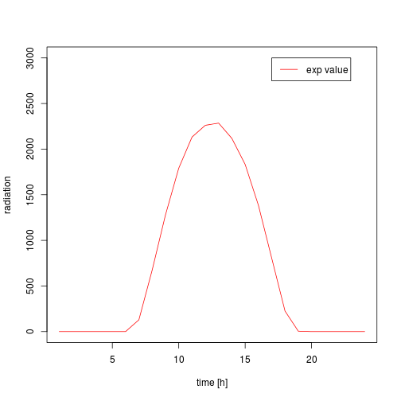

```r
plot(estimates_n_dep$muhat,xlab="time [h]", ylab="radiation", type="l", col="red", ylim=c(0,3000))
legend(17,3000, c("exp value"), col=c("red"), lty=c(1))
```

###Parameter estimation - independent for 15min intervals\

Using the package above it is not possible to analyse a multivariate normal distribution with more than 50 variables, hence we continue the analysis with the assumption of **independently** distributed variables for every 15 minutes.

```r
PV1quh<-matrix(rep(0,(8928*4)),nrow=372) #quarter hourly values -> take means, 24*372=8928
for(i in 1:372){
  for (j in 1:(24*4)){
    PV1quh[i,j]<-mean(PV1[i,((j-1)*15+1):(j*15)])
  }
}

estimates_n_ind<-matrix(rep(0,2*96),nrow=2) #under assumption of independence, 4*24=96=T
for (i in 1:(24*4)){
  estimates_n_ind[1,i]<-fitdistr(PV1quh[,i],"normal")$estimate[1] #estimate of mean (mu)
  estimates_n_ind[2,i]<-fitdistr(PV1quh[,i],"normal")$estimate[2] #estimate of std error (sigma)
  }
estimates_n_ind
```

```
##      [,1] [,2] [,3] [,4] [,5] [,6] [,7] [,8] [,9] [,10] [,11] [,12] [,13]
## [1,]    0    0    0    0    0    0    0    0    0     0     0     0     0
## [2,]    0    0    0    0    0    0    0    0    0     0     0     0     0
##      [,14] [,15] [,16] [,17] [,18] [,19] [,20] [,21] [,22]  [,23] [,24]
## [1,]     0     0     0     0     0     0     0     0     0 0.0717 1.756
## [2,]     0     0     0     0     0     0     0     0     0 0.3018 4.772
##      [,25]  [,26] [,27] [,28] [,29] [,30] [,31] [,32]  [,33]  [,34]  [,35]
## [1,] 30.15  87.52 157.3 240.3 398.0 589.5 774.5 935.5 1079.0 1222.2 1348.3
## [2,] 41.20 101.59 159.1 221.2 268.2 314.9 365.6 435.5  494.4  545.2  593.4
##       [,36]  [,37]  [,38]  [,39]  [,40]  [,41] [,42]  [,43]  [,44]  [,45]
## [1,] 1465.0 1608.6 1768.1 1851.2 1936.3 2017.4  2082 2202.7 2227.5 2262.7
## [2,]  639.4  675.5  706.1  739.9  794.2  857.8   859  840.7  835.9  840.4
##       [,46]  [,47]  [,48] [,49]  [,50]  [,51]  [,52] [,53]  [,54]  [,55]
## [1,] 2226.6 2260.3 2294.4  2297 2296.5 2274.3 2273.5  2240 2167.3 2070.9
## [2,]  881.2  888.3  893.7   905  890.2  875.2  884.6   869  828.5  846.1
##       [,56]  [,57]  [,58]  [,59]  [,60]  [,61]  [,62]  [,63]  [,64]  [,65]
## [1,] 1992.7 1940.1 1891.6 1809.8 1686.9 1540.5 1445.9 1329.4 1217.2 1033.4
## [2,]  849.4  808.9  761.9  730.2  713.2  673.2  617.8  588.3  529.1  479.4
##      [,66] [,67] [,68] [,69] [,70] [,71]  [,72] [,73] [,74]  [,75] [,76]
## [1,] 883.6 732.2 566.0   384 260.1 170.4  86.98 14.34  3.26 0.2626     0
## [2,] 411.4 377.6 342.9   301 222.9 170.6 102.51 29.92 10.05 1.1552     0
##      [,77] [,78] [,79] [,80] [,81] [,82] [,83] [,84] [,85] [,86] [,87]
## [1,]     0     0     0     0     0     0     0     0     0     0     0
## [2,]     0     0     0     0     0     0     0     0     0     0     0
##      [,88] [,89] [,90] [,91] [,92] [,93] [,94] [,95] [,96]
## [1,]     0     0     0     0     0     0     0     0     0
## [2,]     0     0     0     0     0     0     0     0     0
```

Let's visualize the expected value and standard errors we estimated:

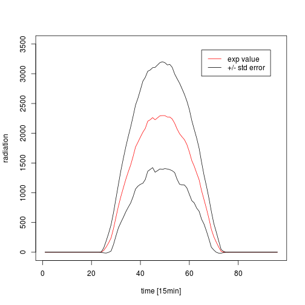

```r
plot(estimates_n_ind[1,],xlab="time [15min]", ylab="radiation", type="l", col="red", ylim=c(0,3500))
lines(estimates_n_ind[1,]+estimates_n_ind[2,],type="l")
lines(estimates_n_ind[1,]-estimates_n_ind[2,],type="l")
legend(65,3400, c("exp value", "+/- std error"), col=c("red","black"), lty=c(1,1))
```

##Sample generation

###Sample generation - dependent for 1h intervals\

We generate a sample of size \( N \) of a **multivariate** normal distribution with the parameters estimated above:

```r
N<-1000
Nsample<-mvrnorm(n=N, estimates_n_dep$muhat, estimates_n_dep$sigmahat)
```

To validate this sample generation, we estimate its distribution and standard error and compare them with the parameters we used:

```r
test<-mlest(Nsample)
diffmu<-estimates_n_dep$muhat-test$muhat
diffsigma<-estimates_n_dep$sigmahat-test$sigmahat
max(diffmu)
```

```
## [1] 4.383
```

```r
max(diffsigma)
```

```
## [1] 3754
```

These values show us that a sample size of \( N=1000 \) is probably not enough. \

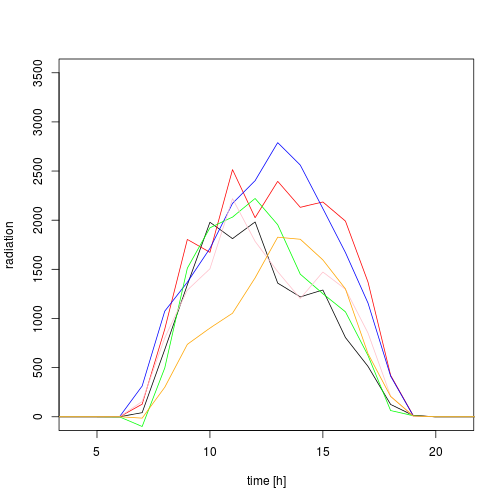

```r
plot(Nsample[1,], type="l", xlim=c(4,21), ylab="radiation", xlab="time [h]", ylim=c(0,3500))
lines(Nsample[2,], type="l", col="red")
lines(Nsample[3,], type="l", col="blue")
lines(Nsample[4,], type="l", col="green")
lines(Nsample[5,], type="l", col="pink")
lines(Nsample[6,], type="l", col="orange")
```

###Sample generation - independent for 15min intervals

We generate a sample of \( N \) **independently** identically distributed random variables of the normal distribution with the parameters estimated above:

```r
N<-10000
N_ind_sample<-matrix(rep(0,24*4*N), ncol=24*4) # 1 column for 1 time interval, 1 row for 1 realization
for(i in 1:N){
N_ind_sample[i,]<-rnorm(24*4,estimates_n_ind[1,], estimates_n_ind[2,])
}
```

To visualize, the first three realizations that were generated, look like this:

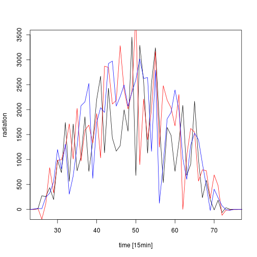

```r
plot(N_ind_sample[1,], type="l", xlim=c(25,75), ylab="radiation", xlab="time [15min]")
lines(N_ind_sample[2,], type="l", col="red")
lines(N_ind_sample[3,], type="l", col="blue")
```

#Weibull distribution\

##Parameter estimation\

###Parameter estimation - independent for 15min intervals\

```r
estimates_w_ind<-matrix(rep(0,2*96),nrow=2) #under assumption of independence
# for (i in 1:(4*24)){
#   coli<-PV1quh[,i]
#   coli<-coli[coli>0]
#   if(length(coli)>0){
#   estimates_w_ind[1,i]<-fitdist(coli,"weibull", lower=c(0,0))$estimate[1] #estimate of shape paramter
#   estimates_w_ind[2,i]<-fitdist(coli,"weibull", lower=c(0,0))$estimate[2] #estimate of scale parameter
#   } else {
#     estimates_w_ind[1,i]<-NaN
#     estimates_w_ind[2,i]<-NaN
#   }
#   }
# estimates_w_ind
```

##Sample generation

###Sample generation - independent for 15min intervals\

```r
N<-10000
# W_ind_sample<-matrix(rep(0,24*4*N), ncol=24*4) # 1 column for 1 time interval, 1 row for 1 realization
# for(i in 1:N){
# W_ind_sample[i,]<-rweibull(24*4,estimates_w_ind[1,i], estimates_w_ind[2,i])
# }
```